# Metabo-Diet R appendix

Metabolomics Workbench live retrieval with a validated cached-JSON fallback

2026-08-17

# 1 How to use the R companion

This R Markdown file follows the same five lesson keys as the primary Python notebook. Read the matching guide lesson, then run the R chunks from top to bottom. If a check fails, stop and review the output. Record your interpretation in the worksheet. The Python notebook is the main activity; this file shows the same retrieval and analysis steps in R.

| Learner guide | R companion section | Main action |
| --- | --- | --- |
| Lesson 1 | `NB-R-L1` | Confirm setup, configuration, and scientific boundary |
| Lesson 2 | `NB-R-L2` | Retrieve endpoints and derive biological sample structure |
| Lesson 3 | `NB-R-L3` | Audit RefMet overlap and labeled standards |
| Lesson 4 | `NB-R-L4` | Run separate within-study PCA examples |
| Lesson 5 | `NB-R-L5` | State the transfer boundary and record session information |

# 2 Environment setup (`NB-R-SETUP`)

To read the companion without installing anything, open the pre-rendered `module/notebooks/metabo_diet_R_appendix.html` in a browser.

To rerun it, install R 4.3 or later from https://cran.r-project.org/ plus RStudio or another Pandoc installation. From the directory that contains `module/`, check Pandoc, install the cached-path packages, and render:

```bash
Rscript -e 'stopifnot(rmarkdown::pandoc_available()); rmarkdown::pandoc_version()'
Rscript module/notebooks/install_r_packages.R
Rscript -e 'rmarkdown::render("module/notebooks/metabo_diet_R_appendix.Rmd")'
```

The default installer covers `rmarkdown`, `knitr`, `jsonlite`, `data.table`, and `httr`. The validated cache does not require network access after installation. To test optional live retrieval, run `Rscript module/notebooks/install_r_packages.R --live` first, then set `METABO_DIET_LIVE=1` before rendering.

```r
required_packages <- c("rmarkdown", "knitr", "jsonlite", "data.table", "httr")
missing_packages <- required_packages[
  !vapply(required_packages, requireNamespace, quietly = TRUE, FUN.VALUE = logical(1))
]
if (getRversion() < "4.3.0") stop("Use R 4.3 or later")
if (length(missing_packages)) {
  stop(
    "Missing R packages: ", paste(missing_packages, collapse = ", "),
    ". Run module/notebooks/install_r_packages.R and render again."
  )
}
cat("R", as.character(getRversion()), "environment check passed\n")
```

```
## R 4.5.2 environment check passed
```

# 3 Lesson 1 companion - Scope and guardrails (`NB-R-L1`)

This appendix reproduces the core data-ingest, metadata, RefMet-overlap, and PCA logic in R. It uses the public diet study **ST001521** and exercise study **ST003348**. Quantitative matrices are analyzed **within one study and one analysis**; they are never stacked across studies.

The default path is deterministic and offline-capable. Set `METABO_DIET_LIVE=1` to try `metabolomicsWorkbenchR::do_query()` for each split endpoint. If the package, network, response, or schema is unavailable, the code falls back endpoint-by-endpoint to the validated JSON cache.

Confirm the two accessions below. Then write one sentence explaining why a shared RefMet name supports a naming comparison but not pooled raw intensities.

## 3.1 Configuration and path discovery

```r
DIET_ACCESSION <- "ST001521"
EXERCISE_ACCESSION <- "ST003348"
DIET_ANALYSIS_ID <- "AN002534"
EXERCISE_ANALYSIS_ID <- "AN005483"
MW_ENDPOINTS <- c("summary", "factors", "analysis", "metabolites", "data")
PREFER_LIVE_API <- identical(Sys.getenv("METABO_DIET_LIVE", "0"), "1")

find_module_dir <- function(start = normalizePath(getwd())) {
  current <- start
  repeat {
    if (dir.exists(file.path(current, "data", "raw")) &&
        dir.exists(file.path(current, "notebooks"))) return(current)
    nested <- file.path(current, "module")
    if (dir.exists(file.path(nested, "data", "raw"))) return(nested)
    parent <- dirname(current)
    if (identical(parent, current)) break
    current <- parent
  }
  stop("Could not locate module/data/raw")
}

MODULE_DIR <- find_module_dir()
RAW_DIR <- file.path(MODULE_DIR, "data", "raw")
DERIVED_DIR <- file.path(MODULE_DIR, "data", "derived")
dir.create(DERIVED_DIR, recursive = TRUE, showWarnings = FALSE)
NORMALIZATION_SCRIPT <- file.path(MODULE_DIR, "scripts", "metabo_diet_R_normalization.R")
if (!file.exists(NORMALIZATION_SCRIPT)) stop("Missing R normalization helpers: ", NORMALIZATION_SCRIPT)
source(NORMALIZATION_SCRIPT)

cat("Retrieval mode:", if (PREFER_LIVE_API) "live with cache fallback" else "validated cache", "\n")
```

```
## Retrieval mode: validated cache
```

```r
cat("Diet accession:", DIET_ACCESSION, "\n")
```

```
## Diet accession: ST001521
```

```r
cat("Exercise accession:", EXERCISE_ACCESSION, "\n")
```

```
## Exercise accession: ST003348
```

# 4 Lesson 2 companion - Comparing study design (`NB-R-L2`)

Run the retrieval and factor chunks in order. Record endpoint source, samples, participants, specimen, conditions, and time meaning for each study. Stop if a factor check fails.

## 4.1 Split REST retrieval with cache fallback

The official Bioconductor interface accepts the MW context, input field, accession, and output item. `fetch_endpoint()` makes one query per endpoint rather than treating study metadata and data as one undifferentiated response.

`metabolomicsWorkbenchR` reshapes the responses. Flat endpoints become data frames, factors become lists by study, and data become lists by analysis. It also changes sample IDs such as `9002-3-PA` to `9002.3.PA`. The normalization script converts live and cached results to the same structure and restores IDs from the factor table. See the official [Bioconductor package page](https://bioconductor.org/packages/release/bioc/html/metabolomicsWorkbenchR.html) for the released implementation and documentation.

```r
fetch_endpoint <- function(study_id, endpoint, prefer_live = FALSE,
                           expected_sample_ids = NULL) {
  url <- paste(
    "https://www.metabolomicsworkbench.org/rest/study/study_id",
    study_id, endpoint, sep = "/"
  )
  cache_path <- file.path(RAW_DIR, paste0(study_id, "_", endpoint, ".json"))
  fallback_reason <- if (prefer_live) "" else "live retrieval disabled for deterministic run"

  if (prefer_live && requireNamespace("metabolomicsWorkbenchR", quietly = TRUE)) {
    live <- tryCatch(
      metabolomicsWorkbenchR::do_query(
        context = "study",
        input_item = "study_id",
        input_value = study_id,
        output_item = endpoint
      ),
      error = function(error) error
    )
    if (!inherits(live, "error")) {
      canonical_live <- tryCatch(
        normalize_mw_endpoint(study_id, endpoint, live, expected_sample_ids),
        error = function(error) error
      )
      if (!inherits(canonical_live, "error")) {
        return(list(
          payload = canonical_live,
          source = data.frame(
            study_id = study_id, endpoint = endpoint, source = "live metabolomicsWorkbenchR",
            url = url, cache_path = cache_path, fallback_reason = "",
            canonical_records = mw_endpoint_record_count(endpoint, canonical_live)
          )
        ))
      }
      fallback_reason <- paste("live normalization failed:", conditionMessage(canonical_live))
    } else {
      fallback_reason <- conditionMessage(live)
    }
  } else if (prefer_live) {
    fallback_reason <- "metabolomicsWorkbenchR is not installed"
  }

  if (!file.exists(cache_path)) stop("Missing cached endpoint: ", cache_path)
  cached <- jsonlite::fromJSON(cache_path, simplifyVector = FALSE)
  canonical_cached <- normalize_mw_endpoint(
    study_id, endpoint, cached, expected_sample_ids
  )
  list(
    payload = canonical_cached,
    source = data.frame(
      study_id = study_id, endpoint = endpoint, source = "validated cache",
      url = url, cache_path = cache_path, fallback_reason = fallback_reason,
      canonical_records = mw_endpoint_record_count(endpoint, canonical_cached)
    )
  )
}

studies <- list()
source_rows <- list()
row_index <- 1L
for (study_id in c(DIET_ACCESSION, EXERCISE_ACCESSION)) {
  studies[[study_id]] <- list()
  for (endpoint in MW_ENDPOINTS) {
    expected_sample_ids <- NULL
    if (endpoint == "data") {
      expected_sample_ids <- vapply(
        studies[[study_id]]$factors,
        function(record) as.character(record$local_sample_id),
        character(1)
      )
    }
    fetched <- fetch_endpoint(
      study_id, endpoint, PREFER_LIVE_API, expected_sample_ids
    )
    studies[[study_id]][[endpoint]] <- fetched$payload
    source_rows[[ row_index]] <- fetched$source
    row_index <- row_index + 1L
  }
}
source_log <- do.call(rbind, source_rows)
stopifnot(nrow(source_log) == 10L)
source_log[, c("study_id", "endpoint", "source", "canonical_records", "url")]
```

| study_id | endpoint | source | canonical_records | url |
| --- | --- | --- | --- | --- |
| ST001521 | summary | validated cache | 1 | https://www.metabolomicsworkbench.org/rest/study/study_id/ST001521/summary |
| ST001521 | factors | validated cache | 160 | https://www.metabolomicsworkbench.org/rest/study/study_id/ST001521/factors |
| ST001521 | analysis | validated cache | 4 | https://www.metabolomicsworkbench.org/rest/study/study_id/ST001521/analysis |
| ST001521 | metabolites | validated cache | 567 | https://www.metabolomicsworkbench.org/rest/study/study_id/ST001521/metabolites |
| ST001521 | data | validated cache | 567 | https://www.metabolomicsworkbench.org/rest/study/study_id/ST001521/data |
| ST003348 | summary | validated cache | 1 | https://www.metabolomicsworkbench.org/rest/study/study_id/ST003348/summary |
| ST003348 | factors | validated cache | 76 | https://www.metabolomicsworkbench.org/rest/study/study_id/ST003348/factors |
| ST003348 | analysis | validated cache | 2 | https://www.metabolomicsworkbench.org/rest/study/study_id/ST003348/analysis |
| ST003348 | metabolites | validated cache | 593 | https://www.metabolomicsworkbench.org/rest/study/study_id/ST003348/metabolites |
| ST003348 | data | validated cache | 593 | https://www.metabolomicsworkbench.org/rest/study/study_id/ST003348/data |

## 4.2 Tidy the longitudinal factors

```r
records_list <- function(payload) {
  if (is.data.frame(payload)) {
    return(lapply(seq_len(nrow(payload)), function(index) as.list(payload[index, , drop = FALSE])))
  }
  unname(payload)
}

flat_records_df <- function(payload) {
  rows <- records_list(payload)
  do.call(rbind, lapply(rows, function(row) {
    flat <- vapply(row, function(value) {
      if (length(value) == 0L || is.null(value)) "" else as.character(value[[1L]])
    }, character(1))
    as.data.frame(as.list(flat), stringsAsFactors = FALSE)
  }))
}

parse_factor_string <- function(value) {
  pieces <- trimws(strsplit(value, "|", fixed = TRUE)[[1L]])
  parsed <- lapply(pieces, function(piece) {
    location <- regexpr(":", piece, fixed = TRUE)[1L]
    if (location < 1L) stop("Malformed factor component: ", piece)
    c(key = trimws(substr(piece, 1L, location - 1L)),
      value = trimws(substr(piece, location + 1L, nchar(piece))))
  })
  keys <- vapply(parsed, `[[`, character(1), "key")
  values <- vapply(parsed, `[[`, character(1), "value")
  if (anyDuplicated(keys)) stop("Duplicate factor key")
  stats::setNames(values, keys)
}

diet_factors_raw <- flat_records_df(studies[[DIET_ACCESSION]]$factors)
exercise_factors_raw <- flat_records_df(studies[[EXERCISE_ACCESSION]]$factors)

diet_biological <- diet_factors_raw[!grepl("^QPP(?:0[1-9]|10)$", diet_factors_raw$local_sample_id), ]
diet_parsed <- lapply(diet_biological$factors, parse_factor_string)
diet_tidy <- data.frame(
  study_id = DIET_ACCESSION,
  local_sample_id = diet_biological$local_sample_id,
  participant_id = sub("-.*$", "", diet_biological$local_sample_id),
  specimen_harmonized = "plasma",
  condition_original = vapply(diet_parsed, `[[`, character(1), "Study_Diet"),
  time_original = vapply(diet_parsed, `[[`, character(1), "Time"),
  stringsAsFactors = FALSE
)

exercise_parsed <- lapply(exercise_factors_raw$factors, parse_factor_string)
exercise_tidy <- data.frame(
  study_id = EXERCISE_ACCESSION,
  local_sample_id = exercise_factors_raw$local_sample_id,
  participant_id = sub("_.*$", "", exercise_factors_raw$local_sample_id),
  specimen_harmonized = "serum",
  condition_original = "acute endurance exercise",
  time_original = tolower(vapply(exercise_parsed, `[[`, character(1), "Collection_time")),
  stringsAsFactors = FALSE
)

suffix_time <- c(`1` = "rest", `2` = "stat", `3` = "rec3", `4` = "rec22")
observed_suffix <- sub("^.*_", "", exercise_tidy$local_sample_id)
stopifnot(all(unname(suffix_time[observed_suffix]) == exercise_tidy$time_original))
stopifnot(nrow(diet_tidy) == 150L, length(unique(diet_tidy$participant_id)) == 30L)
stopifnot(nrow(exercise_tidy) == 76L, length(unique(exercise_tidy$participant_id)) == 19L)

tidy_factors <- rbind(diet_tidy, exercise_tidy)
aggregate(local_sample_id ~ study_id, tidy_factors, function(x) length(unique(x)))
```

| study_id | local_sample_id |
| --- | --- |
| ST001521 | 150 |
| ST003348 | 76 |

# 5 Lesson 3 companion - Harmonizing metabolomics and metadata (`NB-R-L3`)

Predict the raw overlap, inspect the labeled-standard collisions, and trace one retained RefMet name to the source names and analysis IDs in both studies.

## 5.1 RefMet overlap and conservative standard cleanup

```r
diet_metabolites <- flat_records_df(studies[[DIET_ACCESSION]]$metabolites)
exercise_metabolites <- flat_records_df(studies[[EXERCISE_ACCESSION]]$metabolites)

nonblank_refmet <- function(values) unique(values[!is.na(values) & nzchar(values) & values != "-"])
diet_refmet <- nonblank_refmet(diet_metabolites$refmet_name)
exercise_refmet <- nonblank_refmet(exercise_metabolites$refmet_name)
raw_overlap <- intersect(diet_refmet, exercise_refmet)

# Explicit hyphenated stable-isotope suffixes; this does not misclassify vitamin D3.
is_standard <- grepl("-[dD][0-9]+$|-\\[(13C|15N)\\][0-9]*$",
                     exercise_metabolites$metabolite_name, perl = TRUE)
standard_rows <- exercise_metabolites[is_standard, ]
standard_collision_labels <- intersect(nonblank_refmet(standard_rows$refmet_name), raw_overlap)
conservative_overlap <- setdiff(raw_overlap, standard_collision_labels)

overlap_counts <- data.frame(
  metric = c(
    "diet unique nonblank RefMet", "exercise unique nonblank RefMet",
    "raw exact overlap", "exercise isotope/internal-standard rows",
    "raw-overlap labels with a standard collision", "conservative biological overlap"
  ),
  value = c(
    length(diet_refmet), length(exercise_refmet), length(raw_overlap),
    nrow(standard_rows), length(standard_collision_labels), length(conservative_overlap)
  )
)
stopifnot(identical(overlap_counts$value, c(510L, 475L, 153L, 10L, 8L, 145L)))
overlap_counts
```

| metric | value |
| --- | --- |
| diet unique nonblank RefMet | 510 |
| exercise unique nonblank RefMet | 475 |
| raw exact overlap | 153 |
| exercise isotope/internal-standard rows | 10 |
| raw-overlap labels with a standard collision | 8 |
| conservative biological overlap | 145 |

```r
standard_rows[, c("analysis_id", "metabolite_name", "refmet_name")]
```

|  | analysis_id | metabolite_name | refmet_name |
| --- | --- | --- | --- |
| 29 | AN005483 | AcCa(12:0)-D9 | CAR 12:0 |
| 30 | AN005483 | AcCa(18:0)-D3 | CAR 18:0 |
| 53 | AN005483 | Clenbuterol-D9 |  |
| 97 | AN005483 | Hippuric acid-D5 | Hippuric acid |
| 152 | AN005483 | Lysine-d4 | Standard |
| 295 | AN005483 | Taurine-D4 | Taurine |
| 404 | AN005484 | CDCA-D4 | Chenodeoxycholic acid |
| 407 | AN005484 | Chloramphenicol-D5 | Chloramphenicol |
| 547 | AN005484 | Palmitic acid-[13C]16 | Palmitic acid |
| 568 | AN005484 | Stearic acid-D35 | Stearic acid |

The 145-name result is deliberately conservative: if any ST003348 labeled-standard row points to a RefMet label, that label is omitted from the overlap even when another reported row appears unlabeled. When available, the Python-generated `metabolite_crosswalk.csv` supplies the release’s richer class, evidence, confidence, and decision fields. The fallback below keeps the R companion runnable on its own and clearly labels its narrower exact-name audit.

```r
crosswalk_path <- file.path(DERIVED_DIR, "metabolite_crosswalk.csv")
if (file.exists(crosswalk_path)) {
  crosswalk <- read.csv(crosswalk_path, check.names = FALSE, stringsAsFactors = FALSE)
} else {
  collapse_values <- function(values) {
    values <- values[!is.na(values) & nzchar(values)]
    paste(sort(unique(values)), collapse = ";")
  }
  summarize_names <- function(table, prefix) {
    selected <- table[
      table$refmet_name %in% conservative_overlap,
      c("refmet_name", "metabolite_name", "analysis_id")
    ]
    summarized <- stats::aggregate(
      cbind(metabolite_name, analysis_id) ~ refmet_name,
      data = selected,
      FUN = collapse_values
    )
    names(summarized) <- c(
      "refmet_name",
      paste0(prefix, "_source_reported_names"),
      paste0(prefix, "_analysis_ids")
    )
    summarized
  }
  crosswalk <- merge(
    data.frame(refmet_name = sort(conservative_overlap)),
    summarize_names(diet_metabolites, "diet"),
    by = "refmet_name",
    all.x = TRUE
  )
  crosswalk <- merge(
    crosswalk,
    summarize_names(exercise_metabolites, "exercise"),
    by = "refmet_name",
    all.x = TRUE
  )
  crosswalk$main_class <- "not classified in the R fallback"
  crosswalk$mapping_confidence <- "exact repository RefMet name; source role reviewed"
}
stopifnot(nrow(crosswalk) == 145L)
head(crosswalk[, c(
  "refmet_name", "main_class", "diet_source_reported_names", "diet_analysis_ids",
  "exercise_source_reported_names", "exercise_analysis_ids", "mapping_confidence"
)], 8L)
```

|  | refmet_name | main_class | diet_source_reported_names | diet_analysis_ids | exercise_source_reported_names | exercise_analysis_ids | mapping_confidence |
| --- | --- | --- | --- | --- | --- | --- | --- |
| 1 | 1,7-Dimethyluric acid | Purines | 1,7-Dimethyluric acid | AN002533; AN002536 | 1,7-Dimethyluric acid | AN005484 | repository-provided RefMet mapping; nomenclature bridge only |
| 2 | 1-Methyl nicotinamide | Pyridine alkaloids | 1-Methyl nicotinamide | AN002533 | 1-Methylnicotinamide | AN005483 | repository-provided RefMet mapping; nomenclature bridge only |
| 3 | 1-Methyladenosine | Purines | 1-Methyladenosine | AN002533 | 1-Methyladenosine | AN005483 | repository-provided RefMet mapping; nomenclature bridge only |
| 4 | 12,13-DiHOME | Octadecanoids | 12,13-DiHOME | AN002536 | 12,13-DHOME | AN005484 | repository-provided RefMet mapping; nomenclature bridge only |
| 5 | 2-Aminocaprylic acid | Fatty acids | 2-Aminooctanoic acid | AN002533; AN002536 | 2-Aminooctanoic acid | AN005483 | repository-provided RefMet mapping; nomenclature bridge only |
| 6 | 2-Hydroxyglutaric acid | Fatty acids | 2-Hydroxyglutaric acid | AN002535 | 2-Hydroxyglutaric acid | AN005484 | repository-provided RefMet mapping; nomenclature bridge only |
| 7 | 2-Hydroxymyristic acid | Fatty acids | 2-Hydroxymyristic acid | AN002536 | 2-Hydroxymyristic acid(FFA(14:0-OH) | AN005484 | repository-provided RefMet mapping; nomenclature bridge only |
| 8 | 2-Methylguanosine | Purines | 2-Methylguanosine | AN002533 | 2-Methylguanosine | AN005483 | repository-provided RefMet mapping; nomenclature bridge only |

# 6 Lesson 4 companion - Guided analysis and interpretation (`NB-R-L4`)

Run each PCA separately. Record the preprocessing, sample counts, and explained variance, then write an interpretation that includes other explanations and the limit of the claim.

## 6.1 Separate PCA in R

The R path uses the same preprocessing contract as Python: biological samples only, explicit labeled-standard exclusion for ST003348, no more than 20% missingness, `log2(x + 1)`, feature-median imputation, removal of constant features, and feature autoscaling. PCA signs may flip relative to Python without changing the solution.

```r
pca_one_analysis <- function(study_id, analysis_id, payload, factors,
                             exclude_standards = FALSE, max_missing = 0.20) {
  selected <- Filter(
    function(row) identical(as.character(row$analysis_id[[1L]]), analysis_id),
    records_list(payload)
  )
  sample_ids <- factors$local_sample_id
  matrices <- list()
  retained_names <- character()

  for (row in selected) {
    reported <- as.character(row$metabolite_name[[1L]])
    isotope_row <- grepl("-[dD][0-9]+$|-\\[(13C|15N)\\][0-9]*$", reported, perl = TRUE)
    if (exclude_standards && isotope_row) next
    data_values <- row$DATA
    if (is.data.frame(data_values)) data_values <- as.list(data_values[1L, ])
    values <- vapply(sample_ids, function(sample_id) {
      value <- data_values[[sample_id]]
      if (is.null(value) || length(value) == 0L || is.na(value[[1L]])) NA_real_
      else as.numeric(value[[1L]])
    }, numeric(1))
    if (mean(is.na(values)) <= max_missing) {
      matrices[[length(matrices) + 1L]] <- values
      retained_names <- c(retained_names, paste(study_id, analysis_id,
                                                 as.character(row$metabolite_id[[1L]]), sep = "|"))
    }
  }
  matrix <- do.call(cbind, matrices)
  colnames(matrix) <- retained_names
  logged <- log2(matrix + 1)
  for (column in seq_len(ncol(logged))) {
    missing <- is.na(logged[, column])
    logged[missing, column] <- stats::median(logged[, column], na.rm = TRUE)
  }
  nonconstant <- apply(logged, 2L, stats::sd) > 0
  fitted <- stats::prcomp(logged[, nonconstant, drop = FALSE], center = TRUE, scale. = TRUE)
  list(
    study_id = study_id,
    analysis_id = analysis_id,
    samples = nrow(logged),
    input_features = length(selected),
    pca_features = sum(nonconstant),
    variance_percent = 100 * fitted$sdev^2 / sum(fitted$sdev^2),
    scores = cbind(factors, PC1 = fitted$x[, 1L], PC2 = fitted$x[, 2L])
  )
}
```

```r
diet_pca <- pca_one_analysis(
  DIET_ACCESSION, DIET_ANALYSIS_ID, studies[[DIET_ACCESSION]]$data,
  diet_tidy, exclude_standards = FALSE
)
exercise_pca <- pca_one_analysis(
  EXERCISE_ACCESSION, EXERCISE_ANALYSIS_ID, studies[[EXERCISE_ACCESSION]]$data,
  exercise_tidy, exclude_standards = TRUE
)

pca_summary <- do.call(rbind, lapply(list(diet_pca, exercise_pca), function(result) {
  data.frame(
    study_id = result$study_id,
    analysis_id = result$analysis_id,
    samples = result$samples,
    input_features = result$input_features,
    pca_features = result$pca_features,
    PC1_variance_percent = result$variance_percent[1L],
    PC2_variance_percent = result$variance_percent[2L]
  )
}))
stopifnot(
  identical(pca_summary$samples, c(150L, 76L)),
  identical(pca_summary$pca_features, c(212L, 313L))
)
pca_summary
```

| study_id | analysis_id | samples | input_features | pca_features | PC1_variance_percent | PC2_variance_percent |
| --- | --- | --- | --- | --- | --- | --- |
| ST001521 | AN002534 | 150 | 224 | 212 | 34.35914 | 11.62384 |
| ST003348 | AN005483 | 76 | 319 | 313 | 16.11468 | 8.41749 |

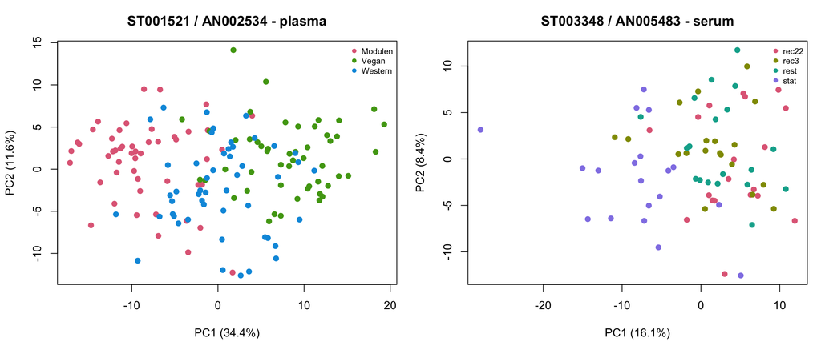

Separate within-study PCA examples. The coordinate systems are independent and must not be compared directly.

```r
plot_pca_scores <- function(result, group, title) {
  group <- factor(group)
  colors <- grDevices::hcl.colors(nlevels(group), palette = "Dark 3")
  graphics::plot(
    result$scores$PC1,
    result$scores$PC2,
    col = colors[as.integer(group)],
    pch = 19,
    xlab = sprintf("PC1 (%.1f%%)", result$variance_percent[1L]),
    ylab = sprintf("PC2 (%.1f%%)", result$variance_percent[2L]),
    main = title
  )
  graphics::legend(
    "topright",
    legend = levels(group),
    col = colors,
    pch = 19,
    cex = 0.72,
    bty = "n"
  )
}

old_parameters <- graphics::par(mfrow = c(1L, 2L), mar = c(4.2, 4.2, 3.0, 1.0))
plot_pca_scores(
  diet_pca,
  diet_pca$scores$condition_original,
  "ST001521 / AN002534 - plasma"
)
plot_pca_scores(
  exercise_pca,
  exercise_pca$scores$time_original,
  "ST003348 / AN005483 - serum"
)
```

```r
graphics::par(old_parameters)
```

**Accessible interpretation.** The left panel contains 150 diet-study plasma samples and colors the deposited diet groups. The right panel contains 76 exercise-study serum samples and colors rest/recovery timepoints. Both axes report model-specific explained variance. Because each PCA was fit independently, positions and axis values cannot be compared across panels.

# 7 Lesson 5 companion - Access transfer and interpretation (`NB-R-L5`)

These PCAs are exploratory, not causal tests or repeated-measures models. In FARMM, days 9 to 15 reflect more than diet alone; in `ST003348`, time also varies with fasting and clock time. A later analysis could fit a longitudinal model within each study and compare effect directions and uncertainty instead of raw peak-area values.

Use the learner-guide transfer checklist to document an exact dataset and action, dated first-party evidence, the compute boundary, permitted outputs, unresolved requirements, and a `GO`, `REVISE`, `WAIT`, or `STOP` decision. Keep credentials and governed data out of this file.